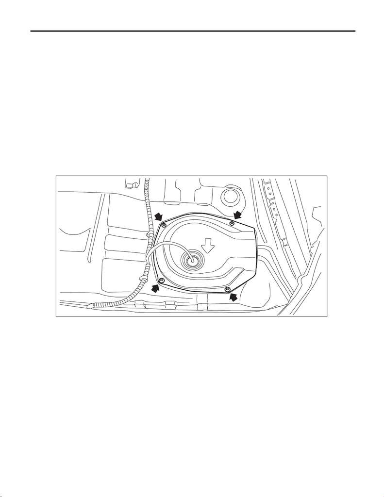

FU(w/o STI)-176

Fuel Sub Level Sensor

FUEL INJECTION (FUEL SYSTEMS)

38.Fuel Sub Level Sensor

A: REMOVAL

WARNING:

Place “NO OPEN FLAMES” signs near the working area.

CAUTION:

• Be careful not to spill fuel.

• Catch the fuel from the tubes using a container or cloth.

• If the fuel gauge indicates that two thirds or more of the fuel is remaining, be sure to drain fuel be-

fore starting work to avoid the fuel to spill.

1) Release the fuel pressure. <Ref. to FU(w/o STI)-146, RELEASING OF FUEL PRESSURE, PROCE-

DURE, Fuel.>

2) Drain fuel. <Ref. to FU(w/o STI)-146, DRAINING FUEL (WITH SUBARU SELECT MONITOR), PROCE-

DURE, Fuel.>

3) Disconnect the ground terminal from battery sensor. <Ref. to NT-5, BATTERY, NOTE, Note.>

4) Remove the rear seat cushion. <Ref. to SE-29, REMOVAL, Rear Seat.>

5) Remove the service hole cover of fuel sub level sensor.

FU-06419

15WRX_STI_US_EN.book 176 ページ ２０１５年２月１３日 金曜日 午前１１時２０分

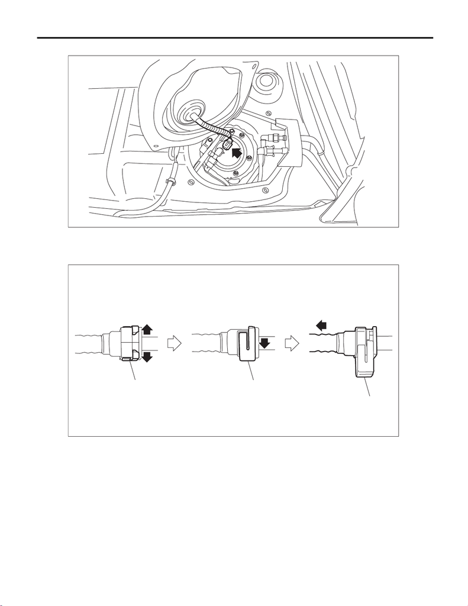

FU(w/o STI)-177

Fuel Sub Level Sensor

FUEL INJECTION (FUEL SYSTEMS)

6) Disconnect the connector from the fuel sub level sensor, and move aside the service hole cover.

7) Disconnect the quick connector of the jet pump tube.

NOTE:

Disconnect the quick connector as shown in the figure.

(a) Slider

FU-06420

EC-02771

(a)

(a)

(a)

15WRX_STI_US_EN.book 177 ページ ２０１５年２月１３日 金曜日 午前１１時２０分

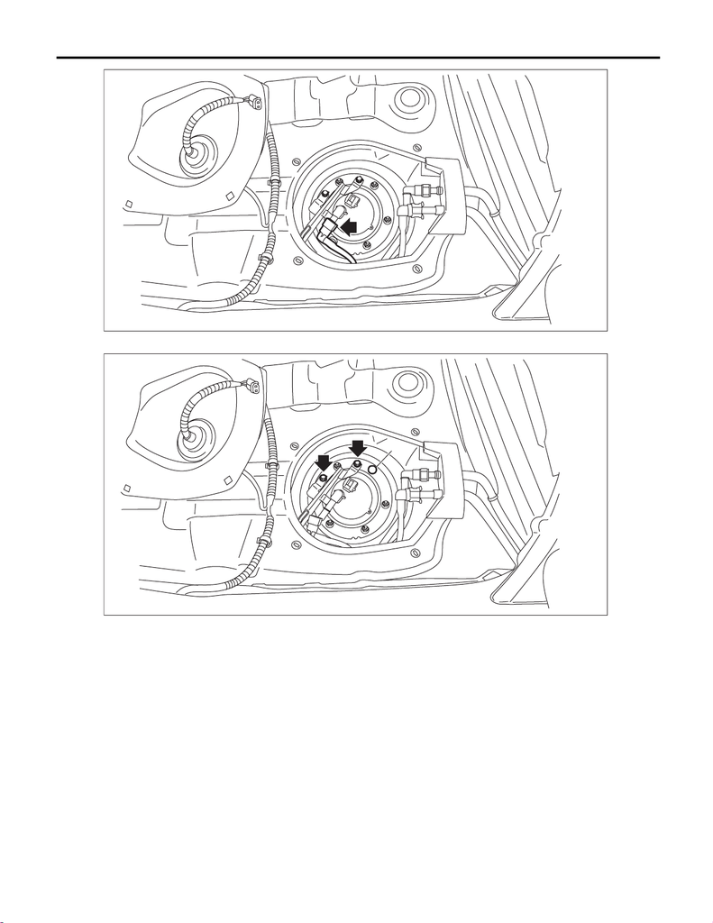

FU(w/o STI)-178

Fuel Sub Level Sensor

FUEL INJECTION (FUEL SYSTEMS)

8) Remove the fuel sub level sensor protector, and remove the rubber cap (A) from nut.

FU-06437

FU-06593

(A)

15WRX_STI_US_EN.book 178 ページ ２０１５年２月１３日 金曜日 午前１１時２０分

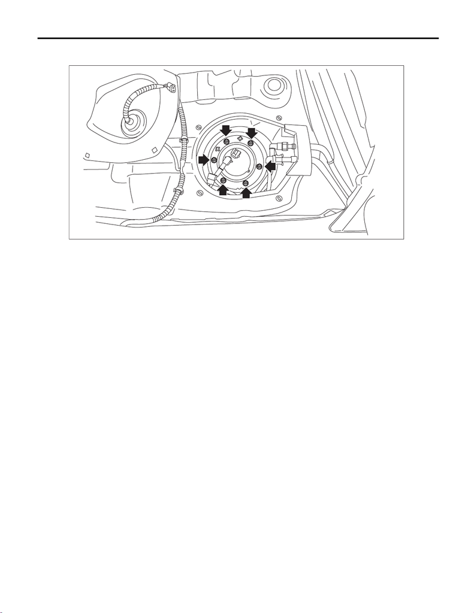

FU(w/o STI)-179

Fuel Sub Level Sensor

FUEL INJECTION (FUEL SYSTEMS)

9) Remove the bolts and nuts which hold fuel sub level sensor protector and fuel sub level sensor upper plate

to the fuel tank.

10) Remove the fuel sub level sensor from the fuel tank.

CAUTION:

Be careful not to let the arm and float of the fuel sub level sensor contact the fuel tank.

FU-06439

15WRX_STI_US_EN.book 179 ページ ２０１５年２月１３日 金曜日 午前１１時２０分

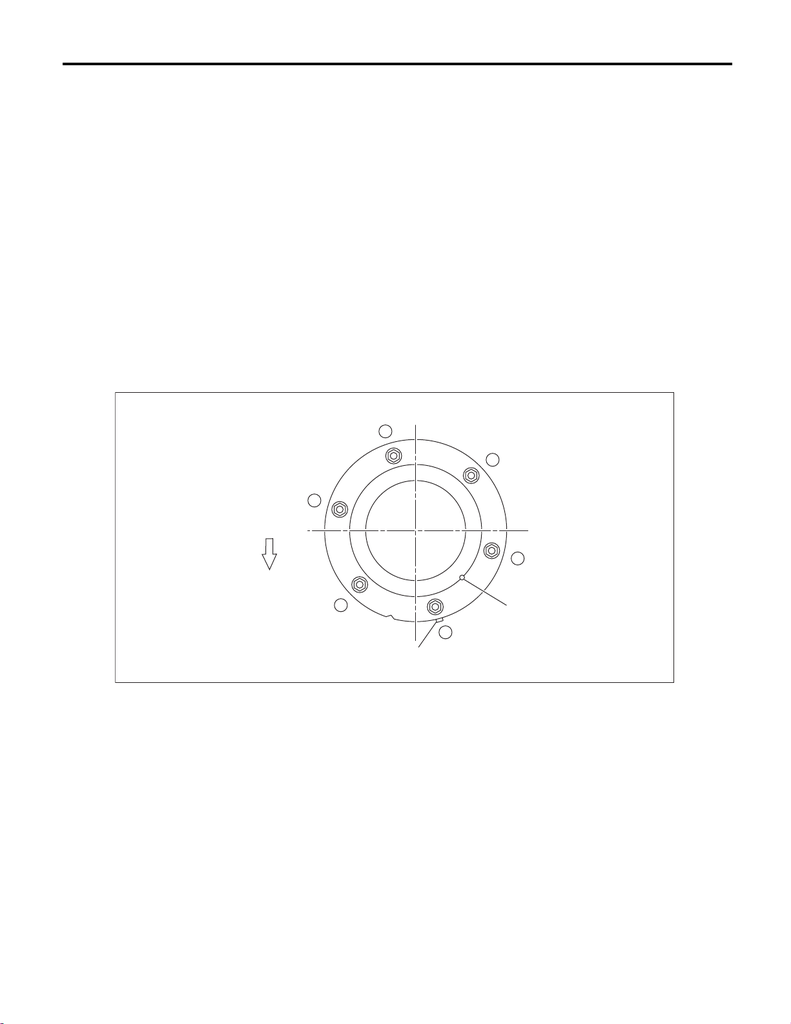

FU(w/o STI)-180

Fuel Sub Level Sensor

FUEL INJECTION (FUEL SYSTEMS)

B: INSTALLATION

Install in the reverse order of removal while being careful of the following.

CAUTION:

Set the arm and float of the fuel sub level sensor while paying attention to prevent them from con-

tacting the fuel tank. If the arm of the fuel sub level sensor is bent, the fuel gauge may not read cor-

rectly.

• Make sure the sealing portion is free from fuel or foreign matter before installation.

• Align protrusion (A) of the gasket to the position shown in the figure.

• Align the cutout of fuel sub level sensor upper plate cushion with the protrusion (B) of fuel sub level sensor.

• Align the protrusion (B) of fuel sub level sensor upper plate cushion with the cutout of fuel sub level sensor

upper plate.

• Tighten the nuts and bolts to the specified torque in the order as shown in the figure.

• After tightening, install the rubber cap (C) at the position shown in the figure.

NOTE:

• Use a new gasket.

• Do not forget to install rubber cap (C).

Tightening torque:

4.4 N·m (0.4 kgf-m, 3.2 ft-lb)

(a) Front side of vehicle

FU-06053

1

6

5

2

4

3

(B)

(A)

(a)

15WRX_STI_US_EN.book 180 ページ ２０１５年２月１３日 金曜日 午前１１時２０分

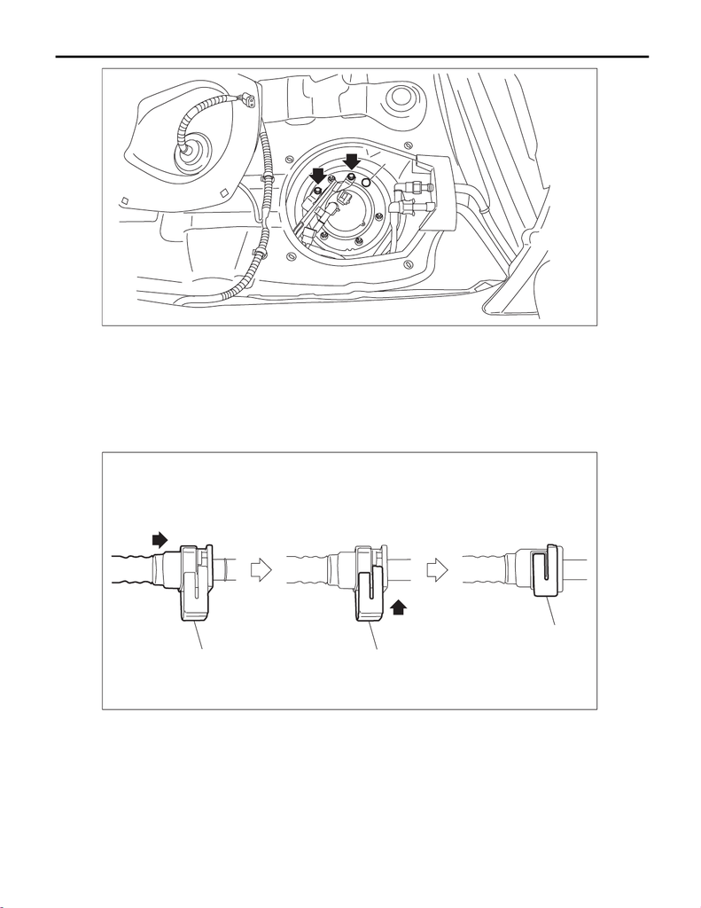

FU(w/o STI)-181

Fuel Sub Level Sensor

FUEL INJECTION (FUEL SYSTEMS)

• Connect the quick connector as shown in the figure.

CAUTION:

• Check that there is no damage or dust on the quick connector. If necessary, clean the seal sur-

face of the pipe.

• When connecting the quick connector, make sure to insert it all the way in before locking the

slider.

• When it is difficult to lock the slider, check that the connector is fully inserted.

• After locking the slider, check again that the quick connector is securely connected.

(a) Slider

FU-06438

(C)

EC-02779

(a)

(a)

(a)

15WRX_STI_US_EN.book 181 ページ ２０１５年２月１３日 金曜日 午前１１時２０分

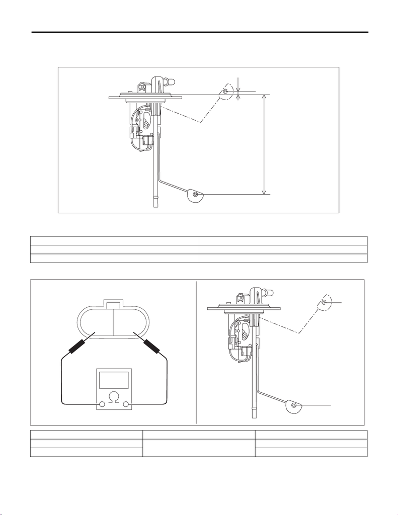

FU(w/o STI)-182

Fuel Sub Level Sensor

FUEL INJECTION (FUEL SYSTEMS)

C: INSPECTION

1) Check that the fuel sub level sensor has no damage.

2) Measure the fuel sub level sensor float position.

3) Measure the resistance between fuel sub level sensor terminals.

(1) FULL (2) EMPTY (3) Datum points

Float position Standard

FULL to Datum point (A) 5.31±3.5 mm (0.209±0.138 in)

EMPTY to Datum point (B) 160.6±3.5 mm (6.32±0.138 in)

Float position Terminal No. Standard

FULL (A)

1 and 2

8.7±1.0 Ω

EMPTY (B) 270.9±4.0 Ω

FU-05969

(1)

(B)

(2)

(A)

(3)

FU-05970

21

(B)

(A)

15WRX_STI_US_EN.book 182 ページ ２０１５年２月１３日 金曜日 午前１１時２０分